# Análise de Séries Temporais: Exercícios de Econometria

Lucas

20 de outubro de 2025

# Introdução

Este documento apresenta a resolução de uma série de exercícios de econometria focados em análise de séries temporais. O objetivo é explorar desde a construção de testes estatísticos de baixo nível até a especificação e o diagnóstico de modelos ARIMA, utilizando a linguagem R.

Abordaremos os seguintes tópicos: 1. **Implementação Manual do Teste de Ljung-Box**: Para testar a presença de autocorrelação. 2. **Cálculo Manual de Critérios de Informação (AIC/BIC)**: Para seleção de modelos autorregressivos. 3. **Tratamento de Séries Não-Estacionárias**: Análise de uma série com tendência e sazonalidade. 4. **Modelagem ARIMA**: Especificação e diagnóstico completo de um modelo para dados econômicos.

## Exercício 7: Teste de Autocorrelação (Ljung-Box)

Aqui, o objetivo é realizar o teste de autocorrelação em diferentes séries temporais.

### 1. Construção da Função `teste_ljung_box_manual`

A função abaixo calcula a estatística Q de Ljung-Box, que segue a fórmula: $Q = n(n+2) \sum_{j=1}^{k} \frac{\hat{\rho}_j^2}{n-j}$.

```r
teste_ljung_box_manual <- function(serie, k) { # serie e qttd de lags
  n <- length(serie)
  media_serie <- mean(serie)
  autocorrelacoes <- numeric(k) # Vetor para guardar as autocorrelações

  # Calcula a variância (autocovariância no lag 0)
  gamma_0 <- sum((serie - media_serie)^2) / n

  # Loop para calcular a autocovariância e autocorrelação para cada lag j
  for (j in 1:k) {
    termo1 <- serie[(j+1):n] - media_serie
    termo2 <- serie[1:(n-j)] - media_serie
    gamma_j <- sum(termo1 * termo2) / n
    autocorrelacoes[j] <- gamma_j / gamma_0
  }

  # Calcula a estatística Q de Ljung-Box
  soma_Q <- sum(autocorrelacoes^2 / (n - (1:k)))
  estatistica_Q <- n * (n + 2) * soma_Q

  # Calcula o p-valor usando a distribuição Qui-Quadrado com 'k' graus de liberdade
  p_valor <- pchisq(estatistica_Q, df = k, lower.tail = FALSE)

  return(list(Q = estatistica_Q, p_valor = p_valor))
}
```

### 2. Aplicação da Função

#### (I) Teste na série $y_t \sim ARIMA(1,1,1)$

Primeiro, simulamos uma série não estacionária e aplicamos o teste. A hipótese nula (H₀) do teste de Ljung-Box é que não há autocorrelação.

```r
# Gerando a série y_t
set.seed(123)
modelo_arima <- list(order = c(1, 1, 1), ar = 0.8, ma = -0.4)
y_t <- arima.sim(model = modelo_arima, n = 500)

# Testando com lags 1 e 5
resultado_y_lag1 <- teste_ljung_box_manual(y_t, k = 1)
resultado_y_lag5 <- teste_ljung_box_manual(y_t, k = 5)

cat("--- Teste em y_t (ARIMA) ---\n")
```

```
## --- Teste em y_t (ARIMA) ---
```

```r
cat("Lag = 1: p-valor =", resultado_y_lag1$p_valor, "\n")
```

```
## Lag = 1: p-valor = 4.358269e-110
```

```r
cat("Lag = 5: p-valor =", resultado_y_lag5$p_valor, "\n")
```

```
## Lag = 5: p-valor = 0
```

**Interpretação:** Os p-valores são extremamente baixos. Com um nível de significância de 5%, **rejeitamos a H₀**. A conclusão é que a série $y_t$ possui autocorrelação significativa, como esperado de um processo ARIMA.

#### (II) Teste em uma série Ruído Branco $z_t$

Agora, aplicamos o teste a uma série de ruído branco, que, por definição, não deve ter autocorrelação.

```r
# Gerando a série z_t (Ruído Branco)
set.seed(456)
z_t <- rnorm(n = 200, mean = 0, sd = sqrt(5))

# Testando com lags 1 e 5
resultado_z_lag1 <- teste_ljung_box_manual(z_t, k = 1)
resultado_z_lag5 <- teste_ljung_box_manual(z_t, k = 5)

cat("--- Teste em z_t (Ruído Branco) ---\n")
```

```
## --- Teste em z_t (Ruído Branco) ---
```

```r
cat("Lag = 1: p-valor =", resultado_z_lag1$p_valor, "\n")
```

```
## Lag = 1: p-valor = 0.8422126
```

```r
cat("Lag = 5: p-valor =", resultado_z_lag5$p_valor, "\n")
```

```
## Lag = 5: p-valor = 0.6107627
```

**Interpretação:** Os p-valores são altos (bem maiores que 0.05). Portanto, **não rejeitamos a H₀**. Concluímos que não há evidência de autocorrelação, o que está correto para um ruído branco.

## Seleção de Modelos com AIC e BIC

Aqui, implementamos uma função para calcular os critérios de informação AIC e BIC para diferentes ordens de modelos AR(p), com o objetivo de encontrar o modelo mais parcimonioso.

### 1. Função `calcular_aic_bic_manual`

```r
calcular_aic_bic_manual <- function(serie, p) {
  serie <- na.omit(as.numeric(serie))
  n_total <- length(serie)

  if (p == 0) {
    modelo <- lm(serie ~ 1)
    n <- n_total
    k <- 1
  } else {
    dados_regressao <- embed(serie, p + 1)
    y_t <- dados_regressao[, 1]
    lags <- dados_regressao[, -1]
    modelo <- lm(y_t ~ lags)
    n <- nrow(dados_regressao)
    k <- p + 1
  }

  sqr <- sum(residuals(modelo)^2)
  aic <- 2 * k + n * log(sqr / n)
  bic <- k * log(n) + n * log(sqr / n)

  return(data.frame(p = p, AIC = aic, BIC = bic))
}
```

### 2. Aplicação da Função

#### (I) Análise do Random Walk

A primeira diferença de um *random walk* é um ruído branco. Esperamos que os critérios identifiquem um modelo AR(0) como o melhor.

```r
set.seed(908293847)
eps <- rnorm(200)
serie_rw_diff <- diff(cumsum(eps))

resultados_rw <- do.call(rbind, lapply(0:5, function(p) calcular_aic_bic_manual(serie_rw_diff, p)))

cat("--- Resultados para a série diferenciada do Random Walk ---\n")
```

```
## --- Resultados para a série diferenciada do Random Walk ---
```

```r
print(resultados_rw)
```

```
##   p      AIC      BIC
## 1 0 10.57234 13.86565
## 2 1 10.41949 16.99602
## 3 2 12.85600 22.70561
## 4 3 11.84142 24.95388
## 5 4 11.57525 27.94025
## 6 5 14.48397 34.09112
```

```r
cat("\nMelhor modelo (menor valor): AIC -> p=", resultados_rw$p[which.min(resultados_rw$AIC)],
    "| BIC -> p=", resultados_rw$p[which.min(resultados_rw$BIC)], "\n")
```

```
##
## Melhor modelo (menor valor): AIC -> p= 1 | BIC -> p= 0
```

#### (II) Análise de um processo AR(2)

Agora, simulamos um processo AR(2) e verificamos se os critérios conseguem identificar a ordem correta.

```r
set.seed(42)
serie_ar2 <- as.numeric(stats::filter(rnorm(200), c(0.8, -0.3), "recursive"))

resultados_ar2 <- do.call(rbind, lapply(0:5, function(p) calcular_aic_bic_manual(serie_ar2, p)))

cat("\n--- Resultados para a série AR(2) ---\n")
```

```
##
## --- Resultados para a série AR(2) ---
```

```r
print(resultados_ar2)
```

```
##   p         AIC       BIC
## 1 0 102.2863708 105.58469
## 2 1   7.3884001  13.97501
## 3 2  -5.6547007   4.21010
## 4 3  -2.7995549  10.33326
## 5 4  -0.2104058  16.18017
## 6 5   1.3928795  21.03088
```

```r
cat("\nMelhor modelo (menor valor): AIC -> p=", resultados_ar2$p[which.min(resultados_ar2$AIC)],
    "| BIC -> p=", resultados_ar2$p[which.min(resultados_ar2$BIC)], "\n")
```

```
##
## Melhor modelo (menor valor): AIC -> p= 2 | BIC -> p= 2
```

**Interpretação:** Tanto o AIC quanto o BIC atingem seu valor mínimo em **p=2**, identificando com sucesso a ordem correta do processo.

## Exercício 8: Análise de Série Sazonal

Este exercício aborda o tratamento da série `a10` (vendas de medicamentos), que apresenta tendência e sazonalidade com variância crescente.

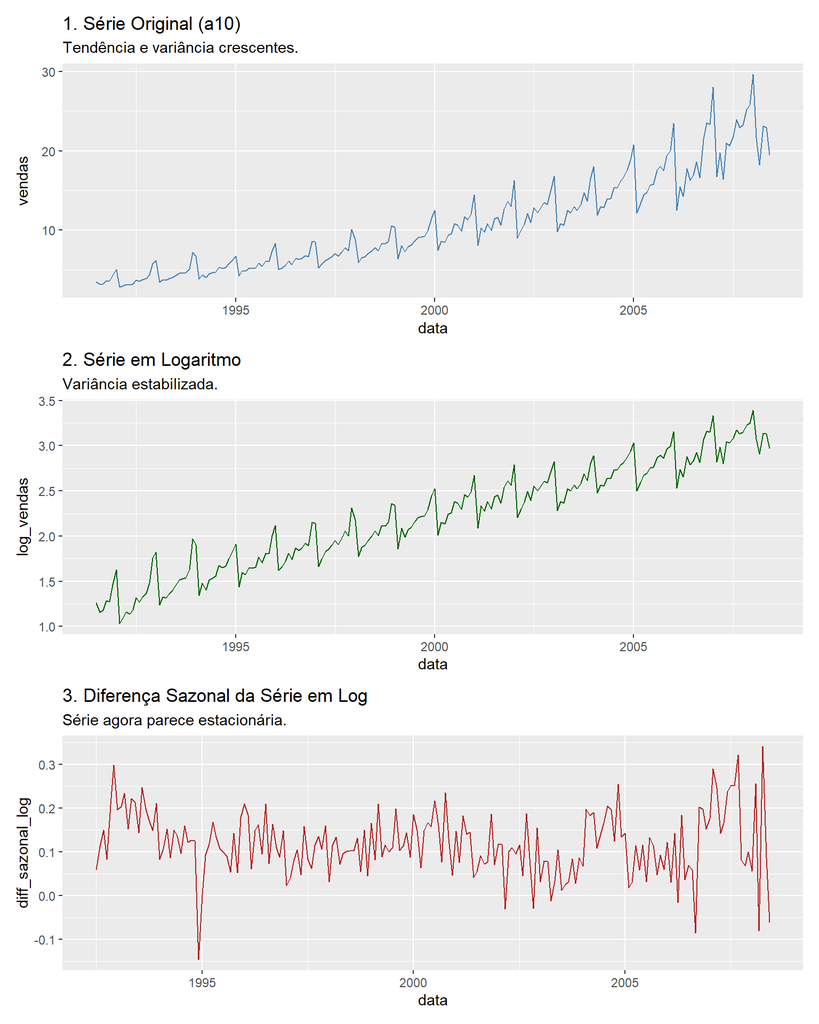

```r
# Carregando pacotes. fpp2 contém o dataset a10.
library(fpp2)
library(ggplot2)
library(patchwork)
library(dplyr)
library(timetk)

# Preparando os dados para ggplot2
dados_a10_df <- tk_tbl(a10, rename_index = "data") %>%
  rename(vendas = value)

# Gráfico 1: Série Original
p1 <- ggplot(dados_a10_df, aes(x = data, y = vendas)) + geom_line(color = "steelblue") +
  labs(title = "1. Série Original (a10)", subtitle = "Tendência e variância crescentes.")

# Gráfico 2: Logaritmo da Série
dados_a10_df$log_vendas <- log(dados_a10_df$vendas)
p2 <- ggplot(dados_a10_df, aes(x = data, y = log_vendas)) + geom_line(color = "darkgreen") +
  labs(title = "2. Série em Logaritmo", subtitle = "Variância estabilizada.")

# Gráfico 3: Diferença Sazonal da Série em Log
dados_a10_df$diff_sazonal_log <- c(rep(NA, 12), diff(dados_a10_df$log_vendas, lag = 12))
p3 <- ggplot(na.omit(dados_a10_df), aes(x = data, y = diff_sazonal_log)) + geom_line(color = "firebrick") +
  labs(title = "3. Diferença Sazonal da Série em Log", subtitle = "Série agora parece estacionária.")

# Combinando os gráficos
(p1 / p2 / p3)
```

**Interpretação:** 1. **Série Original**: Mostra tendência de crescimento e padrão sazonal com amplitude crescente. 2. **Série em Logaritmo**: Estabiliza a variância. 3. **Diferença Sazonal**: Remove a tendência e a sazonalidade, resultando em uma série estacionária pronta para modelagem.

## Exercícios 9 & 10: Modelagem ARIMA Completa

Estes exercícios cobrem o fluxo completo: especificação, estimação e diagnóstico de um modelo para os dados de consumo dos EUA. Usamos o pacote moderno `fpp3` e o dataset `us_change`.

### 1. Análise e Especificação do Modelo (Ex. 9)

Analisamos a série `us_change`, que representa a variação percentual do consumo.

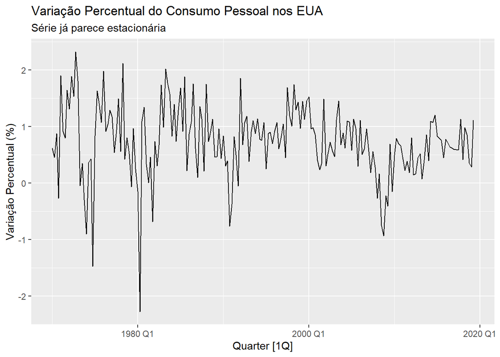

```r
library(fpp3)

# O dado 'us_change' já é a variação percentual, que tende a ser estacionária.
autoplot(us_change, Consumption) +
  labs(title = "Variação Percentual do Consumo Pessoal nos EUA",
       subtitle = "Série já parece estacionária",
       y = "Variação Percentual (%)")
```

**Conclusão inicial:** A série já é estacionária e não precisa de diferenciação (d=0). Vamos analisar suas autocorrelações para sugerir as ordens `p` e `q`.

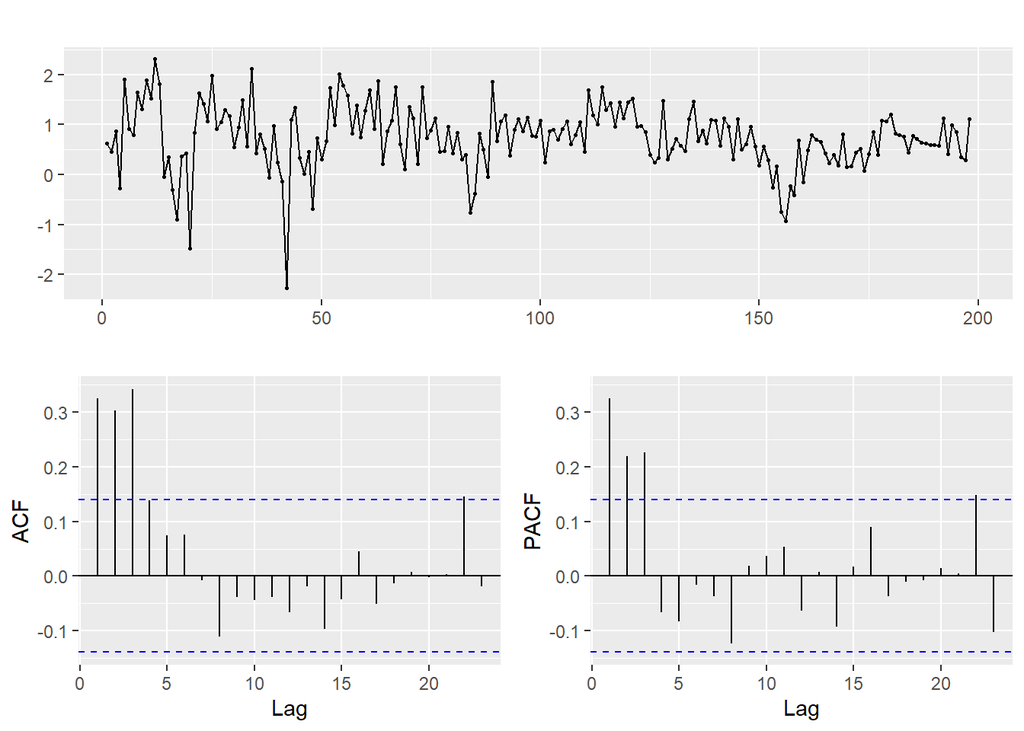

```r
# ggtsdisplay é ideal para visualizar a série e suas autocorrelações
# Usamos $ para selecionar a coluna e passar uma série univariada
ggtsdisplay(us_change$Consumption, lag_max = 20)
```

**Interpretação:** O padrão misto (decaimento em ambas as funções) sugere um modelo **ARMA(p, q)**.

### 2. Estimação e Diagnóstico do Modelo (Ex. 10)

Usamos a função `ARIMA()` do `fpp3` para encontrar o melhor modelo automaticamente e, em seguida, realizamos um diagnóstico completo de seus resíduos.

```r
# Ajusta o melhor modelo ARIMA automaticamente
modelo_final <- us_change %>%
  model(ARIMA(Consumption))

library(fpp3)

# Ajustando os dois modelos em um único comando
comparacao_modelos <- us_change %>%
  model(
    # Modelo 1: Deixa o R escolher o melhor modelo (provavelmente SARIMA)
    modelo_automatico = ARIMA(Consumption),

    # Modelo 2: Força um modelo não-sazonal
    # A mágica está em PDQ(0,0,0), que desliga a parte sazonal
    modelo_nao_sazonal = ARIMA(Consumption ~ PDQ(0,0,0))
  )

# --- Análise dos Resultados ---

# 1. Veja o relatório do modelo automático (o SARIMA)
cat("--- Modelo Automático (SARIMA) ---\n")
```

```
## --- Modelo Automático (SARIMA) ---
```

```r
report(comparacao_modelos %>% select(modelo_automatico))
```

```
## Series: Consumption
## Model: ARIMA(1,0,3)(1,0,1)[4] w/ mean
##
## Coefficients:
##           ar1     ma1     ma2     ma3     sar1    sma1  constant
##       -0.3413  0.5568  0.3208  0.4084  -0.1459  0.3849    1.1392
## s.e.   0.1590  0.1500  0.0922  0.0792   0.2136  0.1806    0.1265
##
## sigma^2 estimated as 0.3324:  log likelihood=-168.58
## AIC=353.16   AICc=353.92   BIC=379.46
```

```r
# 2. Veja o relatório do modelo forçado (ARIMA não-sazonal)
cat("\n\n--- Modelo Forçado (ARIMA Não-Sazonal) ---\n")
```

```
##
##
## --- Modelo Forçado (ARIMA Não-Sazonal) ---
```

```r
report(comparacao_modelos %>% select(modelo_nao_sazonal))
```

```
## Series: Consumption
## Model: ARIMA(1,0,3) w/ mean
##
## Coefficients:
##          ar1      ma1     ma2     ma3  constant
##       0.5731  -0.3617  0.0925  0.1934    0.3160
## s.e.  0.1503   0.1607  0.0787  0.0824    0.0371
##
## sigma^2 estimated as 0.3334:  log likelihood=-169.88
## AIC=351.77   AICc=352.21   BIC=371.5
```

Os resíduos de um bom modelo devem se comportar como ruído branco.

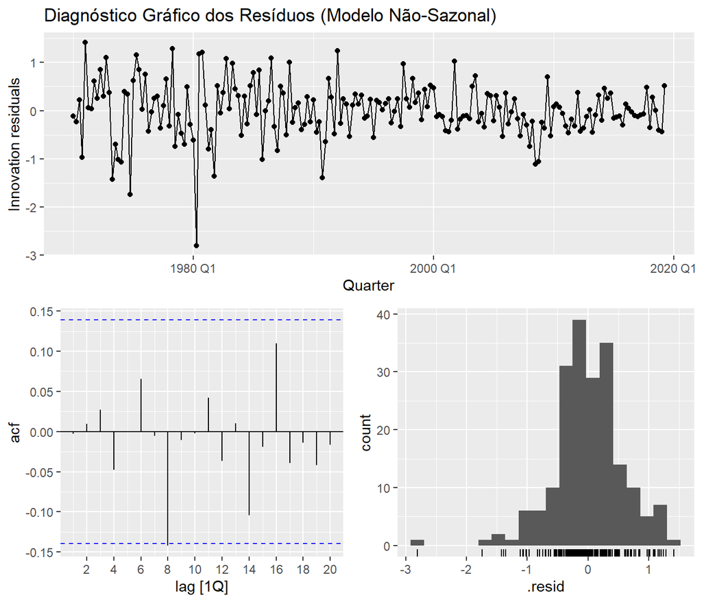

```r
# Carregamos a biblioteca principal
library(fpp3)

# Ajustamos o modelo ARIMA NÃO-SAZONAL
modelo_nao_sazonal <- us_change %>%
  model(ARIMA(Consumption ~ PDQ(0,0,0)))

# Geramos os gráficos de diagnóstico para o modelo NÃO-SAZONAL
gg_tsresiduals(modelo_nao_sazonal, lag_max = 20) +
  labs(title = "Diagnóstico Gráfico dos Resíduos (Modelo Não-Sazonal)")
```

#### Testes Estatísticos Formais

#### 3.4. Validação do Modelo Simplificado (Não-Sazonal)

Para avaliar a necessidade do componente sazonal, ajustamos um modelo ARIMA forçado a ser não-sazonal e realizamos os mesmos testes de diagnóstico.

```r
# Carregamos a biblioteca principal
library(fpp3)

# Ajustamos o modelo ARIMA NÃO-SAZONAL
modelo_nao_sazonal <- us_change %>%
  model(ARIMA(Consumption ~ PDQ(0,0,0)))

# Exibimos o relatório
report(modelo_nao_sazonal)
```

```
## Series: Consumption
## Model: ARIMA(1,0,3) w/ mean
##
## Coefficients:
##          ar1      ma1     ma2     ma3  constant
##       0.5731  -0.3617  0.0925  0.1934    0.3160
## s.e.  0.1503   0.1607  0.0787  0.0824    0.0371
##
## sigma^2 estimated as 0.3334:  log likelihood=-169.88
## AIC=351.77   AICc=352.21   BIC=371.5
```

```r
# Extraímos os resíduos
residuos_nao_sazonais <- residuals(modelo_nao_sazonal)

# Teste de Ljung-Box
ljung_box_result <- residuos_nao_sazonais %>% features(.resid, ljung_box, lag = 20)
cat("\n--- Teste de Ljung-Box (Modelo Não-Sazonal) ---\n")
```

```
##
## --- Teste de Ljung-Box (Modelo Não-Sazonal) ---
```

```r
print(ljung_box_result)
```

```
## # A tibble: 1 × 3
##   .model                            lb_stat lb_pvalue
##   <chr>                               <dbl>     <dbl>
## 1 ARIMA(Consumption ~ PDQ(0, 0, 0))    12.3     0.905
```

```r
# Teste de Jarque-Bera
library(tseries)
jb_test_result <- jarque.bera.test(residuos_nao_sazonais$.resid)
cat("\n--- Teste de Jarque-Bera (Modelo Não-Sazonal) ---\n")
```

```
##
## --- Teste de Jarque-Bera (Modelo Não-Sazonal) ---
```

```r
print(jb_test_result)
```

```
##
##  Jarque Bera Test
##
## data:  residuos_nao_sazonais$.resid
## X-squared = 74.76, df = 2, p-value < 2.2e-16
```